# c8w2_lecture_notes

R. Handsfield

September 14, 2016

# 1 Decision Trees

A *decision tree* is a data structure that shows *conjuctive* (logical `AND`) relationships. You can think of it as a map of binary if-then tests.

A *classification* tree is a binary structure that outputs the class which contains the input data.

A *regression tree* outputs a real number.

A high level interpretation is that you use the input variables to split the outcomes into groups based on feature values, then evaluate the homogeneity of outcomes in each group (splitting again if necessary). This type of analysis is easy to interpret and has good performance, but allows only poor estimates of uncertainty and is prone to overfitting. (Results may not be consistent.)

## 1.1 Decision Tree Algorithm

1. Start with all the features
2. Find the single feature that best separates the outcomes
3. Divide the data into two groups (leaves) on that split (node)
4. Within each leaf, repeat 2-3
5. Continue until groups are sufficiently small or homogenous

## 1.2 Measures of Homogeneity

How do we know when the groups are sufficiently homogenous, or *pure*?

A simple way is to count the fraction of occurrences of class $k$ :

- $N$ is the number of examples in leaf $m$
- $x_i$ is 1 training example
- $y_i$ is the outcome of $x_i$
- $k$ is an output class
- $\delta_{y_i k}$ is the Kronecker delta

$$\mbox{For each leaf } m: ~~ \hat{p}_{mk} = \frac{1}{N_m} \sum_{x_i}{\delta_{y_i k}}$$

Define also

- $k(m)$ is the *most common* class in leaf $m$
- $\hat{p}_{mk(m)}$ is the probability in leaf $m$ that $y_i = k(m)$

Then the *misclassification error* is
$$ME = 1 - \hat{p}_{mk(m)} ~~~
\left\{\begin{matrix}
ME = 0 & \rightarrow &\mbox{perfect purity}\\
ME = .5 & \rightarrow & \mbox{no purity}
\end{matrix}\right.$$

$ME = 1$ is perfect impurity, or perfect purity for the class “not $k$”. But, since we usually define things in terms of the class $k$, we rarely see $ME = 1$.

Another measure of purity is the **Gini impurity**, which measures the probability that a randomly labeled outcome would be incorrect. It is the product of probabilites $\hat{p}_{mk}$ and $(1-\hat{p}_{mk})$ summed over *all* classes $K$

$$GI =
\sum^{K}_{k=1}{ \hat{p}_{mk} (1 - \hat{p}_{mk}) } ~ = ~
1 - \sum^{K}_{k=1}{ \hat{p^2}_{mk} }$$

$$\left\{\begin{matrix}
GI = 0 & \rightarrow &\mbox{perfect purity}\\
GI = .5 & \rightarrow & \mbox{no purity}
\end{matrix}\right.$$

The **Deviance/Information Gain** measures

$$DG = - \sum^{K}_{k=1}{\hat{p}_{mk} log_e \hat{p}_{mk} }$$
$$IG = - \sum^{K}_{k=1}{\hat{p}_{mk} log_2 \hat{p}_{mk} }$$

$$\left\{\begin{matrix}
D/I = 0 & \rightarrow &\mbox{perfect purity}\\
D/I = 1 & \rightarrow & \mbox{no purity}
\end{matrix}\right.$$

### 1.2.1 Example

Consider the following predictions of a binary (red/blue) tree:

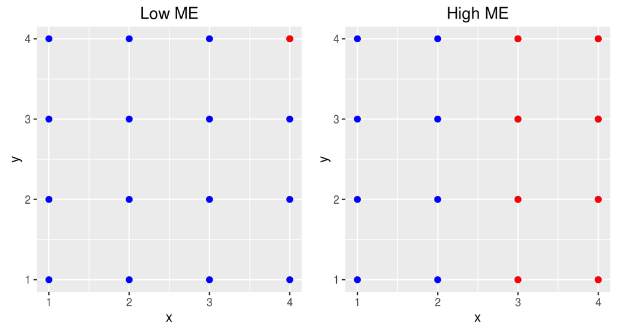

| Low ME | High ME |
| --- | --- |
| $ME = 1/16 = 0.06$ | $ME = 8/16 = 0.5$ |
| $GI = 1 - [(1/16)^2 + (15/16)^2] = 0.12$ | $GI = 1 - [(8/16)^2 + (8/16)^2] = 0.5$ |
| $IG = - \left[\frac{1}{16} log_2 \left(\frac{1}{16} \right) + \frac{15}{16} log_2 \left(\frac{15}{16} \right)\right] = 0.34$ | $IG = - \left[\frac{8}{16} log_2 \left(\frac{8}{16} \right) + \frac{8}{16} log_2 \left(\frac{8}{16} \right)\right] = 1$ |

The tree that produces the right-hand figure is no better than a random binary classifier.

### 1.2.2 Example: Predicting Flower Species

Can we predict a flower’s species from its morphology?

```r
data(iris)

# The variable (feature) names
names(iris)
```

```
## [1] "Sepal.Length" "Sepal.Width"  "Petal.Length" "Petal.Width"
## [5] "Species"
```

```r
# The output classes are the flower species
table(iris$Species)
```

```
##
##     setosa versicolor  virginica
##         50         50         50
```

```r
# Create training sets
inTrain <- createDataPartition(y=iris$Species, p=0.7, list=FALSE)
training <- iris[inTrain, ]; testing <- iris[-inTrain, ];

dim(training); dim(testing)
```

```
## [1] 105   5
```

```
## [1] 45  5
```

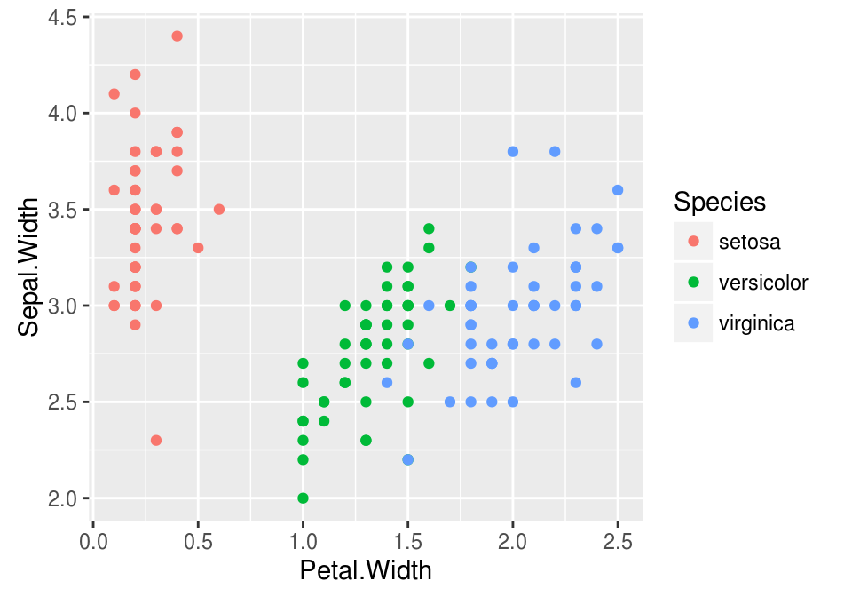

```r
ggplot(data=iris) + aes(x=Petal.Width, y=Sepal.Width, color=Species) + geom_point()
```

Train a decision tree model to predict flower species; use `caret::train(..., method="rpart")`

```r
modFit <- train(form = Species~., method = "rpart", data = training )

# model object is huge and complicated; just view the final model member
print(modFit$finalModel)
```

```
## n= 105
##
## node), split, n, loss, yval, (yprob)
##       * denotes terminal node
##
## 1) root 105 70 setosa (0.33333333 0.33333333 0.33333333)
##   2) Petal.Length< 2.45 35  0 setosa (1.00000000 0.00000000 0.00000000) *
##   3) Petal.Length>=2.45 70 35 versicolor (0.00000000 0.50000000 0.50000000)
##     6) Petal.Width< 1.75 37  2 versicolor (0.00000000 0.94594595 0.05405405) *
##     7) Petal.Width>=1.75 33  0 virginica (0.00000000 0.00000000 1.00000000) *
```

The first node is `root`. There 105 training examples in this node, the loss is 70, the class of interest is `setosa`, and all examples at the root have equal change of being any species.

The second node splits all examples based on $\mbox{Petal.Length} < 2.45$. None of the examples subject to this test are misclassified, and when the condition is true, the examples have 100% probability of being classed as *setosa*.

## 1.3 Linear Discriminant Analysis

Linear Discriminant analysis draws straight lines through the feature space, attempting to separate the data. (Compared to *quadratic* discriminant analysis, which draws curves).

Consider the ratio of probabilities that $Y$ belongs to some class, applying Bayes’ theorem gives

$$log \frac{P(Y=k|X=x)}{P(Y=j|X=x)} = log \frac{f_k(x)}{f_j(x)} + log \frac{\pi_k}{\pi_j}$$

$$= log \frac{\pi_k}{\pi_j} - {1 \over 2}(\mu_k+\mu_j)^T \sigma^{-1}(\mu_k+\mu_j) + x^T \sigma^{-1}(\mu_k-\mu_j)$$

Where $\sigma$ is the covariance matrix.

The decision boundaries are straight lines spoking out from a central point, with a gaussian distribution in each region

Defining the **discriminant function** as

$$\delta_k(x) = x^T \sigma^{-1}\mu_k - {1 \over 2}\mu_k\sigma^{-1}\mu_k + log \mu_k$$

then predictions becomre

$$\hat Y (x) = \mbox{argmax}_k \delta_k(x)$$

In this case, the parameters $\mu_k$ and $\Sigma$ (?) are obtained via [maximum likelihood estimation](https://en.wikipedia.org/wiki/Maximum_likelihood_estimation).

## 1.4 Naive Bayes Classifiers

Naive Bayes Classifiers do the same thing even more simply. For a group of features $(X_1 ... X_n$, applying Bayes’ theorem simplifies to

$$P(Y=k ~|~ X_1 ...X_N) \propto \pi_k P(X_1 ...X_N~|~Y=k)$$

Which expands to

$$P(Y=k ~|~ X_1 ...X_N) \approx \prod^N_{n=1}{P(X_n~|~Y=k)}$$

### 1.4.1 Example: Model Based Classifier

In `caret::train()`, use

- `method="lda"` for linear discriminant classifiers
- `method="nb"` for naive bayes classifiers

Using the `iris` data set

```r
library(ggplot2)

data(iris)
names(iris)
```

```
## [1] "Sepal.Length" "Sepal.Width"  "Petal.Length" "Petal.Width"
## [5] "Species"
```

```r
table(iris$Species)
```

```
##
##     setosa versicolor  virginica
##         50         50         50
```

```r
inTrain <- createDataPartition(y = iris$Species, p = 0.7, list = FALSE)
training <- iris[inTrain,]; testing <- iris[-inTrain,]

dim(training); dim(testing)
```

```
## [1] 105   5
```

```
## [1] 45  5
```

Making predictions with two different methods (lda and naive bayes)

```r
modlda <- train(form = Species~., method="lda", data=training)
modnb <- train(form = Species~., method="nb", data=training)

plda <- predict(object = modlda, newdata = testing)
pnb <- predict(object = modnb, newdata = testing)

table(plda, pnb)
```

```
##             pnb
## plda         setosa versicolor virginica
##   setosa         15          0         0
##   versicolor      0         16         0
##   virginica       0          2        12
```

Compare predictions

```r
equalPredictions <- (plda == pnb)
table(equalPredictions)
```

```
## equalPredictions
## FALSE  TRUE
##     2    43
```

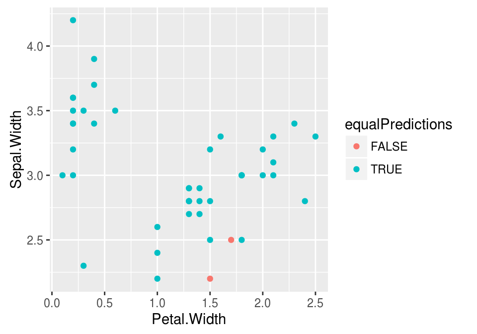

```r
ggplot(data=testing) + aes(x=Petal.Width , y=Sepal.Width, color=equalPredictions) + geom_point()
```